# Predicting the Quantified self

# Prediction Algorithms

#### Predicting with Decision Trees

One can use classification trees and random forests to predict the outcome. Requires library(e1071)

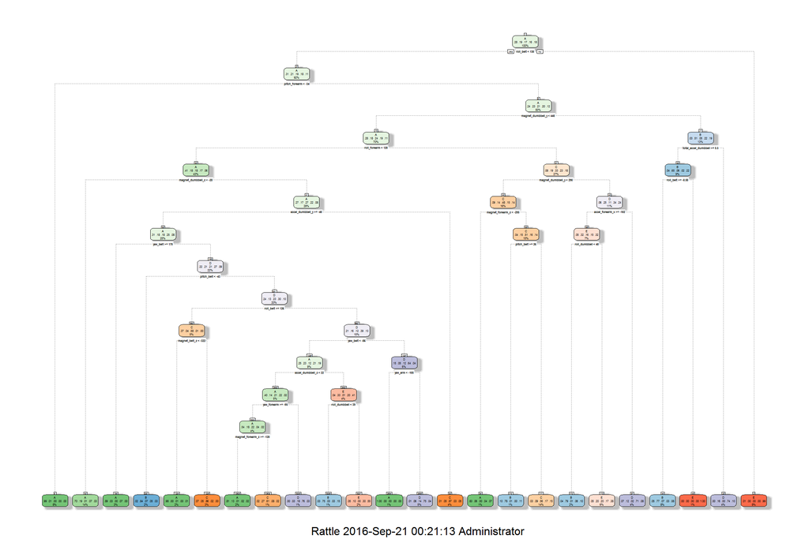

```r
set.seed(10000)
library(e1071)
modelFit1 <- rpart(classe ~ ., data=NewtrainingSet, method="class")
fancyRpartPlot(modelFit1)
```

```r
#------------------------------------------------------------------------
prediction1 <- predict(modelFit1, validationSet, type = "class")
```

Using confusion Matrix to test results:

```r
    confusionMatrix(prediction1, validationSet$classe)
```

```
## Confusion Matrix and Statistics
##
##           Reference
## Prediction    A    B    C    D    E
##          A 1263  165   10   56   27
##          B   33  517   34   25   58
##          C   31   74  662  129  104
##          D   18   61   49  502   40
##          E   27   60   39   86  634
##
## Overall Statistics
##
##                Accuracy : 0.7606
##                  95% CI : (0.7482, 0.7728)
##     No Information Rate : 0.2917
##     P-Value [Acc > NIR] : < 2.2e-16
##
##                   Kappa : 0.6955
##  Mcnemar's Test P-Value : < 2.2e-16
##
## Statistics by Class:
##
##                      Class: A Class: B Class: C Class: D Class: E
## Sensitivity            0.9206   0.5895   0.8338   0.6291   0.7346
## Specificity            0.9226   0.9608   0.9136   0.9570   0.9448
## Pos Pred Value         0.8304   0.7751   0.6620   0.7493   0.7494
## Neg Pred Value         0.9658   0.9108   0.9644   0.9266   0.9406
## Prevalence             0.2917   0.1864   0.1688   0.1696   0.1835
## Detection Rate         0.2685   0.1099   0.1407   0.1067   0.1348
## Detection Prevalence   0.3233   0.1418   0.2126   0.1424   0.1798
## Balanced Accuracy      0.9216   0.7752   0.8737   0.7930   0.8397
```

#### Predicting with Random forests

```r
modelFit2 <- randomForest(classe ~. , data=NewtrainingSet)
```

```r
prediction2 <- predict(modelFit2, validationSet, type = "class")
```

Using confusion Matrix to test results:

```r
confusionMatrix(prediction2, validationSet$classe)
```

```
## Confusion Matrix and Statistics
##
##           Reference
## Prediction    A    B    C    D    E
##          A 1372    0    0    0    0
##          B    0  877    0    0    0
##          C    0    0  794    0    0
##          D    0    0    0  798    0
##          E    0    0    0    0  863
##
## Overall Statistics
##
##                Accuracy : 1
##                  95% CI : (0.9992, 1)
##     No Information Rate : 0.2917
##     P-Value [Acc > NIR] : < 2.2e-16
##
##                   Kappa : 1
##  Mcnemar's Test P-Value : NA
##
## Statistics by Class:
##
##                      Class: A Class: B Class: C Class: D Class: E
## Sensitivity            1.0000   1.0000   1.0000   1.0000   1.0000
## Specificity            1.0000   1.0000   1.0000   1.0000   1.0000
## Pos Pred Value         1.0000   1.0000   1.0000   1.0000   1.0000
## Neg Pred Value         1.0000   1.0000   1.0000   1.0000   1.0000
## Prevalence             0.2917   0.1864   0.1688   0.1696   0.1835
## Detection Rate         0.2917   0.1864   0.1688   0.1696   0.1835
## Detection Prevalence   0.2917   0.1864   0.1688   0.1696   0.1835
## Balanced Accuracy      1.0000   1.0000   1.0000   1.0000   1.0000
```

```r
#Summary results

#accuracy
accuracy <- postResample(prediction2, validationSet$classe)
accuracy
```

```
## Accuracy    Kappa
##        1        1
```

```r
#sample error
error <- 1 - as.numeric(confusionMatrix(validationSet$classe, prediction2)$overall[1])
error
```

```
## [1] 0
```

Accuracy of this prediction model is 100% using the validation set

The out of sample error is just the error rate that we get when we apply the classification model on a new data set.

# Predicting using original Test Data

Apply the model to the original testing data set downloaded from the data source. Generate “problem_id_x.txt” Files for the assignments. These generated individual files are stored in working directory.

```r
Testprediction <- predict(modelFit2, NewtestingSet)
pml_write_files = function(x){
  n = length(x)
  for(i in 1:n){
    filename = paste0("problem_id_",i,".txt")
    write.table(x[i],file=filename,quote=FALSE,row.names=FALSE,col.names=FALSE)
  }
}
pml_write_files(Testprediction)
```

Loaded these files as per Problem_id number into Project Assignment and obtained the correct results for all 20 cases.

# Conclusion